# R Notebook

## Task 1.2 Distribution for each EEG signal

```r
# by calling the function below and inputting the signal/data under investigation a histogram plot,will be populated ,the function also alow us to change axis labels and title.
his<- function(x,input_X,plot_title){
  h <- hist(x, plot=FALSE)
  h$density = h$counts/sum(h$counts) * 100
  plot(h, main=plot_title,
  lines(density(x)),
  xlab=input_X ,
  ylab="Relative frequency %",
  col="blue",
  freq=FALSE)
rug(x)}
```

```r
# lets call the 'his' function to populate some histogram plots
par(mfrow=c(2,2))
his(df$x1,"input_X1","Distribution of EEG signal input x1")
his(df$x2,"input_X2","Distribution of EEG signal input x2")
```

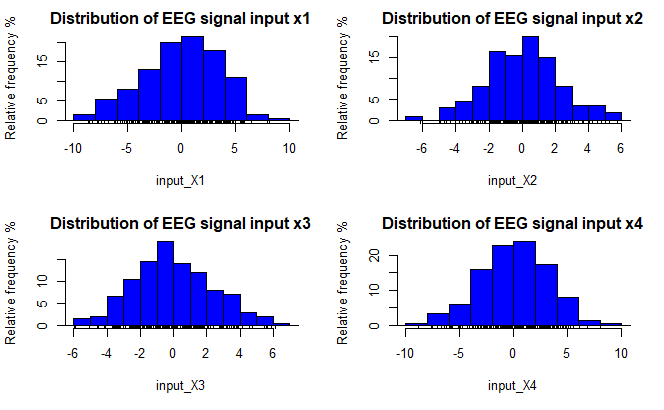

```r
his(df$x3,"input_X3","Distribution of EEG signal input x3")
his(df$x4,"input_X4","Distribution of EEG signal input x4")
```

```r
#  the function below is to plot the histogram and density
#=========================================================
his_density<- function(X,X_lab,title,colour){hist(X,
     main=title,
     xlab=X_lab,
     #ylim=range(0:0.8),
     col=colour,
     cex.main = 1,
     freq=FALSE)
lines(density(X))}
```

```r
# calling the function that was created in the above section 'his_density' and populating histigoram with density plot to check the distribution of the signals

par(mfrow=c(2,2))
his_density(df$x1,"input X1","Distribution of EEG signal input x1","green")
his_density(df$x2,"input X2","Distribution of EEG signal input x2","blue")
```

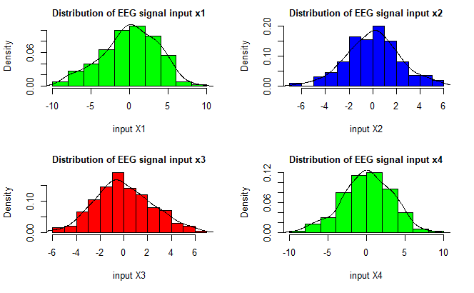

```r
his_density(df$x3,"input X3","Distribution of EEG signal input x3","red")
his_density(df$x4,"input X4","Distribution of EEG signal input x4","green")
```

[output not shown]

[figure not shown]

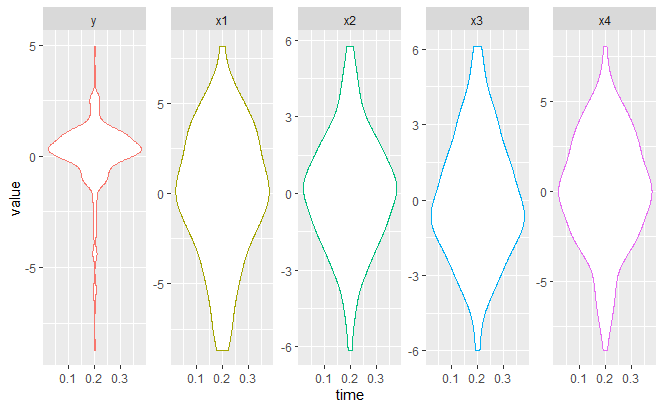

```r
## its good to try differnt approach for that purpose ,violin plot can be plotted using the code below
ggplot(d[c(202:length(d$value)),], aes(x = time,y=value),colour = variable) +
  geom_violin(width=TRUE)+geom_violin(aes(colour = variable))+
  facet_wrap(~ variable, scales = "free_y", nrow  = 1, strip.position = "top")+guides(color=FALSE)# + coord_flip()
```

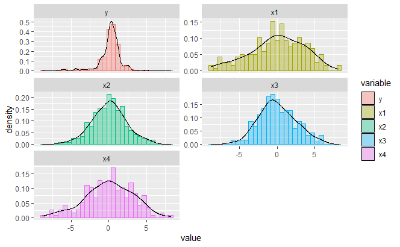

```r
ggplot(d[c(202:length(d$value)),], aes(x=value, color=variable, fill=variable)) +
 geom_histogram(aes(y=..density..), alpha=0.3,
                position="identity")+
 geom_density(alpha=.1,color="black") +facet_wrap(~ variable, scales = "free_y", nrow  = 3, strip.position = "top")+guides(color=FALSE)
```

```r
NA
NA
```

### computing skewness and kurtosis

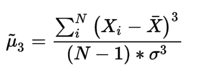

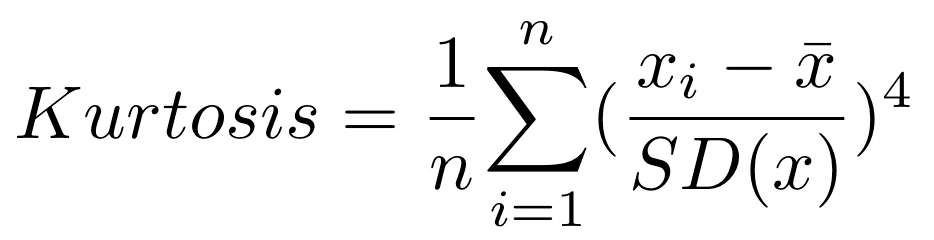

```r
# the function below is for computing the skewness
skew_kur=function(X){
  n=length(df$y)
  skewness = ( sqrt(n) * sum( (X - mean(X))^3 ) ) / (sqrt( sum( (X - mean(X))^2 ) ))^3
return(skewness)}
```

```r
# let's compute the skewness and kurtosis for the signals for better understanding its distribution

print("=== skewness and kurtosis of EEG signals ===")
```

```
[1] "=== skewness and kurtosis of EEG signals ==="
```

```r
print(paste0('skewness of x1 =',skewness(df$x1)))
```

```
[1] "skewness of x1 =-0.316645506912751"
```

```r
print(paste0('kurtosis of x1 =',kurtosis(df$x1)))
```

```
[1] "kurtosis of x1 =-0.354202224109824"
```

```r
print("-------------------------------------------")
```

```
[1] "-------------------------------------------"
```

```r
print(paste0('skewness of x2 =',skewness(df$x2)))
```

```
[1] "skewness of x2 =-0.00643841776422655"
```

```r
print(paste0('kurtosis of x2 =',kurtosis(df$x2)))
```

```
[1] "kurtosis of x2 =0.082290197299463"
```

```r
print("-------------------------------------------")
```

```
[1] "-------------------------------------------"
```

```r
print(paste0('skewness of x3 =',skewness(df$x3)))
```

```
[1] "skewness of x3 =0.20628384481981"
```

```r
print(paste0('kurtosis of x3 =',kurtosis(df$x3)))
```

```
[1] "kurtosis of x3 =-0.239240123724473"
```

```r
print("-------------------------------------------")
```

```
[1] "-------------------------------------------"
```

```r
print(paste0('skewness of x4 =',skewness(df$x4)))
```

```
[1] "skewness of x4 =-0.244740973273576"
```

```r
print(paste0('kurtosis of x4 =',kurtosis(df$x4)))
```

```
[1] "kurtosis of x4 =-0.127709122052018"
```

```r
print("-------------------------------------------")
```

```
[1] "-------------------------------------------"
```

```r
print(paste0('skewness of y =',skewness(df$y)))
```

```
[1] "skewness of y =-2.03678801336605"
```

```r
print(paste0('kurtosis of y =',kurtosis(df$y)))
```

```
[1] "kurtosis of y =8.23341805188544"
```

```r
print("-------------------------------------------")
```

```
[1] "-------------------------------------------"
```

## Correlation and scatter plots (between different input EEG signals and the output EEG) to examine their dependencies

#### Compute correlation matrix

```r
# computing correlation matrxi
res <- cor(df1)
round(res, 2)
```

```
      y   x1   x2   x3   x4
y  1.00 0.73 0.17 0.41 0.57
x1 0.73 1.00 0.26 0.58 0.81
x2 0.17 0.26 1.00 0.52 0.37
x3 0.41 0.58 0.52 1.00 0.71
x4 0.57 0.81 0.37 0.71 1.00
```

#### Use rcorr() function

```r
#using rcorr in R to compute correlation matrix
corr_mat <- function(X,title){res2 <- rcorr(as.matrix(df1),type=X)#c("pearson","spearman"))
ggcorrplot(res2$r,hc.order=TRUE,
           type="full",
           lab_size=3,
           lab = TRUE,
           colors = c("tomato2","red","springgreen3"),
           method="square",
           title=(title),
           ggtheme=theme_bw)}
```

### Visualize correlation matrix

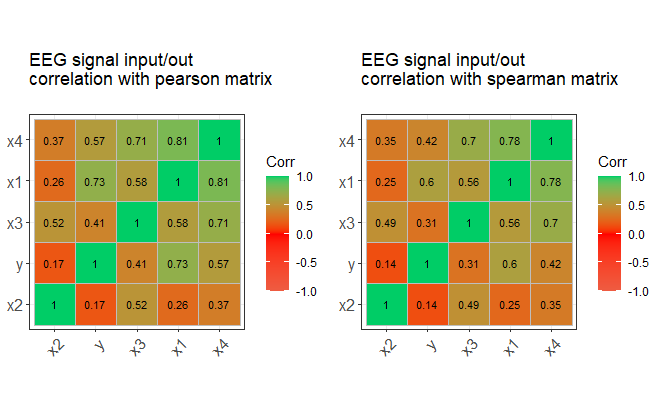

```r
###visualising correlation matrix using gridExtra

require(gridExtra)
grid.arrange(corr_mat("pearson","EEG signal input/out\ncorrelation with pearson matrix\n "),
             corr_mat("spearman","EEG signal input/out\ncorrelation with spearman matrix\n"),
             ncol=2)
```

### scatter plots of EEG signals

**# the function below is to plot scatter for the input/out EEG signal to check dependency ,the function arguments consist of X which can be replaced by the desired data ,xlabel= can be replaced by desired corresponding x label and “meth” the smoothing line to fit can be replaced by the desired line such as lm for linear regression or leoss for polynomial.**

```r
# the function below is to plot scatter for the input/out EEG signal to check dependency ,the function arguments consist of X which can be replaced by the desired data ,xlabel= can be replaced by desired corresponding x label and "meth" the smoothing line to fit can be replaced by the desired line such as lm for linear regression or leoss for polynomial.

scatter_func<- function(X,xlabel,meth){ggplot(df1, aes(x=X, y=y))+
  geom_point(shape=21,xlabel="x1") +
  geom_smooth(method=meth,
              color="red",
              size=0.5,formula=y~x)+xlab(xlabel) + ylab("EEG output signal 'y' ")}
```

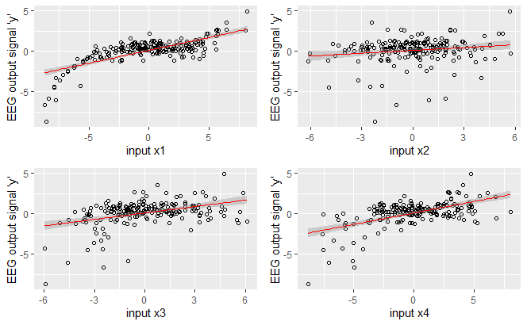

```r
# by calling the function for plotting sactter and using grid.arrenge all the four EEG input signals can be plotted against the output and visualised as two columns


require(gridExtra)
grid.arrange(scatter_func(df$x1,"input x1","lm"),
             scatter_func(df$x2,"input x2","lm"),
             scatter_func(df$x3,"input x3","lm"),
             scatter_func(df$x4,"input x4","lm"),
             ncol=2)
```

```r
NA
NA
```

# Task 2: Regression – modelling the relationship between EEG signals

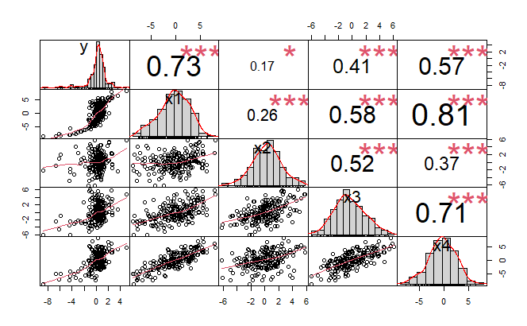

```r
chart.Correlation(df1, histogram=TRUE, pch=19)
```

# Task 2 Linear regression

## Task 2.1

```r
#as.matrix(sapply(df, as.numeric))
```

**The main aim of this task to find the best candidate model that best describes the input and output relationship of the EEG signal**

#### ===The five candidate models are shown below ,from Model1 to Model 5 respectively=

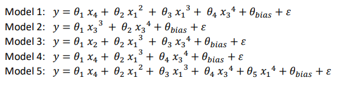

## Estimating the parameters for the five candidate models using Least-square method

```r
# ===computing the estimated paramters for model1===========

x_ones = matrix(1 , length(df$x1),1)
Model_x1 = cbind(df$x4,df$x1^2,df$x1^3,df$x3^4,x_ones)
theta_hat1 <- solve(t(Model_x1) %*% Model_x1)%*%(t(Model_x1) %*% df$y)

# ===computing the estimated paramters for model2===========

Model_x2 = cbind(df$x3^3,df$x3^4,x_ones)
theta_hat2 <- solve(t(Model_x2) %*% Model_x2)%*%(t(Model_x2) %*% df$y)
print(theta_hat2)
```

```
             [,1]
[1,]  0.016334677
[2,] -0.002713985
[3,]  0.303501144
```

```r
# ===computing the estimated paramters for model3===========

Model_x3 = cbind(df$x2,df$x1^3,df$x3^4,x_ones)
theta_hat3 <- solve(t(Model_x3) %*% Model_x3)%*%(t(Model_x3) %*% df$y)


# ===computing the estimated paramters for model4===========

Model_x4 = cbind(df$x4,df$x1^3,df$x3^4,x_ones)
theta_hat4 <- solve(t(Model_x4) %*% Model_x4)%*%(t(Model_x4) %*% df$y)

# ===computing the estimated paramters for model5===========

Model_x5 = cbind(df$x4,df$x1^2,df$x1^3,df$x3^4,df$x1^4,x_ones)
theta_hat5 <- solve(t(Model_x5) %*% Model_x5)%*%(t(Model_x5) %*% df$y)
```

**let’s put the estimated parameters in list and rename for presentation purpose**

```r
#let's put the estimated parameters in list and rename for presentation purpose

Mylist<- list(theta_hat1,theta_hat2,theta_hat3,theta_hat4,theta_hat5)
names(Mylist) <- c("Estimated_parameters_for_model1", "Estimated_parameters_for_model2", "Estimated_parameters_for_model3","Estimated_parameters_for_model4","Estimated_parameters_for_model5")
Mylist
```

```
$Estimated_parameters_for_model1
             [,1]
[1,] -0.034101975
[2,] -0.001849575
[3,]  0.010381813
[4,] -0.001949154
[5,]  0.468551685

$Estimated_parameters_for_model2
             [,1]
[1,]  0.016334677
[2,] -0.002713985
[3,]  0.303501144

$Estimated_parameters_for_model3
             [,1]
[1,]  0.038109255
[2,]  0.009827804
[3,] -0.002092558
[4,]  0.448299550

$Estimated_parameters_for_model4
             [,1]
[1,] -0.034881772
[2,]  0.010482178
[3,] -0.001990496
[4,]  0.450329209

$Estimated_parameters_for_model5
              [,1]
[1,] -3.395313e-02
[2,] -2.701644e-04
[3,]  1.034764e-02
[4,] -1.943452e-03
[5,] -3.083194e-05
[6,]  4.606560e-01
```

## Task 2.2

**Based on the estimated model parameters, compute the model residual (error) sum of squared errors (RSS), for every candidate model**

#### computing The SSE for the first model

```r
# Define a simple function to compute RSS and predicted output
RSS_fun=function(model,theta_hat,y_Hat,RSS,RSS_model){
  y_Hat = model %*% theta_hat
  RSS = sum((y-y_Hat)^2)
  print(paste0(RSS_model ,RSS))
}
RSS_fun1=function(model,theta_hat,y_Hat){
  y_Hat =  model%*%theta_hat
  RSS = sum((y-y_Hat)^2)

}
y_Hat1 = Model_x1 %*% theta_hat1
y_Hat2 = Model_x2 %*% theta_hat2
y_Hat3 = Model_x3 %*% theta_hat3
y_Hat4 = Model_x4 %*% theta_hat4
y_Hat5 = Model_x5 %*% theta_hat5
```

```r
RSS_fun(Model_x1,theta_hat1,y_Hat1,RSS1,'RSS_for_model1 = ')
```

```
[1] "RSS_for_model1 = 57.3292699482937"
```

```r
RSS2=RSS_fun(Model_x2,theta_hat2,y_Hat2,RSS2,'RSS_for_model2 = ')
```

```
[1] "RSS_for_model2 = 351.414664427187"
```

```r
RSS3=RSS_fun(Model_x3,theta_hat3,y_Hat3,RSS3,'RSS_for_model3 = ')
```

```
[1] "RSS_for_model3 = 57.325359212521"
```

```r
RSS4=RSS_fun(Model_x4,theta_hat4,y_Hat4,RSS4,'RSS_for_model4 = ')
```

```
[1] "RSS_for_model4 = 57.4640514418548"
```

```r
RSS5=RSS_fun(Model_x5,theta_hat5,y_Hat5,RSS5,'RSS_for_model5 = ')
```

```
[1] "RSS_for_model5 = 57.3092338627836"
```

```r
RSS1=RSS_fun1(Model_x1,theta_hat1,y_Hat1)
RSS2=RSS_fun1(Model_x2,theta_hat2,y_Hat2)
RSS3=RSS_fun1(Model_x3,theta_hat3,y_Hat3)
RSS4=RSS_fun1(Model_x4,theta_hat4,y_Hat4)
RSS5=RSS_fun1(Model_x5,theta_hat5,y_Hat5)
```

## Task 2.3 (Compute the log-likelihood function for every candidate model:)

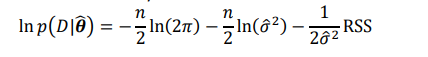

The variance of the model predictions residuals error

**The function below is to compute the log-likelihood function**

```r
# the function below is to compute log-likelihhood function
log_like <- function(RSS){
  N       <- 201
  sigma <- RSS / (N - 1)

  loglik  <-  -.5*N * log(2*pi) - .5*N * log(sigma) - RSS / (2*sigma)
  return(loglik)
}
```

```r
log_likely_function1 = log_like(RSS1)
print(paste0('log-likelihood function for model1 =',log_likely_function1))
```

```
[1] "log-likelihood function for model1 =-159.131286756267"
```

```r
log_likely_function2 = log_like(RSS2)
print(paste0('log-likelihood function for model2 =',log_likely_function2))
```

```
[1] "log-likelihood function for model2 =-341.353423921212"
```

```r
log_likely_function3 = log_like(RSS3)
print(paste0('log-likelihood function for model3 =',log_likely_function3))
```

```
[1] "log-likelihood function for model3 =-159.124430880526"
```

```r
log_likely_function4 = log_like(RSS4)
print(paste0('log-likelihood function for model4 =',log_likely_function4))
```

```
[1] "log-likelihood function for model4 =-159.367285613401"
```

```r
log_likely_function5 = log_like(RSS5)
print(paste0('log-likelihood function for model5 =',log_likely_function5))
```

```
[1] "log-likelihood function for model5 =-159.096156733677"
```

## Task 2.4 (Compute the Akaike information criterion (AIC) and Bayesian information criterion (BIC) for every candidate model:)

```r
# code to compute Akaike information criterion (AIC)
AIC_1 = 2*length(theta_hat1) - 2*log_likely_function1
print(paste0('AIC for model 1 =' ,AIC_1))
```

```
[1] "AIC for model 1 =328.262573512533"
```

```r
AIC_2 = 2*length(theta_hat2) - 2*log_likely_function2
print(paste0('AIC for model 2 =', AIC_2))
```

```
[1] "AIC for model 2 =688.706847842424"
```

```r
AIC_3 = 2*length(theta_hat3) - 2*log_likely_function3
print(paste0('AIC for model 3 =' ,AIC_3))
```

```
[1] "AIC for model 3 =326.248861761052"
```

```r
AIC_4 = 2*length(theta_hat4) - 2*log_likely_function4
print(paste0('AIC for model 4 =', AIC_4))
```

```
[1] "AIC for model 4 =326.734571226802"
```

```r
AIC_5 = 2*length(theta_hat5) - 2*log_likely_function5
print(paste0('AIC for model 5 =' ,AIC_5))
```

```
[1] "AIC for model 5 =330.192313467354"
```

```r
# code to compute Bayesian information criterion (BIC)
N  <- 201
BIC_1 = log(N)*length(theta_hat1) - 2*log_likely_function1
print(paste0('BIC for model 1 =',BIC_1))
```

```
[1] "BIC for model 1 =344.779098052829"
```

```r
BIC_2 = log(N)*length(theta_hat2) - 2*log_likely_function2
print(paste0('BIC for model 2 =',BIC_2))
```

```
[1] "BIC for model 2 =698.616762566601"
```

```r
BIC_3 = log(N)*length(theta_hat3) - 2*log_likely_function3
print(paste0('BIC for model 3 =',BIC_3))
```

```
[1] "BIC for model 3 =339.462081393288"
```

```r
BIC_4 = log(N)*length(theta_hat4) - 2*log_likely_function4
print(paste0('BIC for model 4 =',BIC_4))
```

```
[1] "BIC for model 4 =339.947790859038"
```

```r
BIC_5 = log(N)*length(theta_hat5) - 2*log_likely_function5
print(paste0('BIC for model 5 =',BIC_5))
```

```
[1] "BIC for model 5 =350.012142915708"
```

## Task 2.5 Check the distribution of model prediction errors (residuals) for each candidate model. Plot the error distributions, and evaluate if those distributions are close to Normal/Gaussian (as the output EEG has additive Gaussian noise), e.g. by using Q-Q plot.

```r
error1=df$y-y_Hat1
error2=df$y-y_Hat2
error3=df$y-y_Hat3
error4=df$y-y_Hat4
error5=df$y-y_Hat5
# par(mrow=2)
error_dist=function(error,tit){qqnorm(error,col="red", pch = 1,main = tit, frame = FALSE)
                     qqline(error, col = "steelblue", lwd = 2)

                       }
```

```r
par(mfrow = c(2, 3)) # 2 x 2 pictures on one plot
error_dist(error1,"Normal Q-Q Plot for\n model1 prediction errors")
error_dist(error2,"Normal Q-Q Plot for\n model2 prediction errors")
```

```r
error_dist(error3,"Normal Q-Q Plot for\n model3 prediction errors")
error_dist(error4,"Normal Q-Q Plot for\n model4 prediction errors")
```

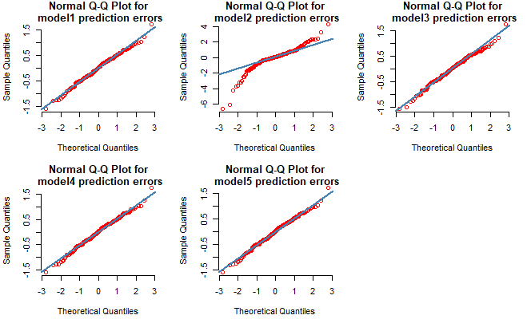

```r
error_dist(error5,"Normal Q-Q Plot for\n model5 prediction errors")
```